# 260-2017-02-22-sex

2017-02-21 11:32:35

## Prelude

[video not shown]

## Today's topics

- Your brain on sex

## Sex and the brain

[interactive chart not shown]

## What hormone is NOT released by the hypothalamus/pituitary system?

- Oxytocin
- Vasopressin
- Melatonin
- Adrenocorticotropic hormone (ACTH)

## What hormone is NOT released by the hypothalamus/pituitary system?

- Oxytocin
- Vasopressin
- Melatonin
- Adrenocorticotropic hormone (ACTH)

## All of the following are components of the SAM axis, *EXCEPT*:

- Midbrain.
- Sympathetic nervous system.
- Adrenal medulla.
- Hypothalamus.

## All of the following are components of the SAM axis, *EXCEPT*:

- Midbrain.
- Sympathetic nervous system.
- Adrenal medulla.
- Hypothalamus.

[figure not shown]

[(Ulrich-Lai and Herman 2009)](http://doi.org/10.1038/nrn2647)

## Factors influencing sexual development

[figure not shown]

## Hormones have

- *Organizing* effects
  - Influence sexual development
- *Activating* effects
  - Influence sexual behavior
- But sexuality in humans is complex

## Types of mating systems

- Promiscuity (both -> multiple)
- Polyandry (female -> multiple males)
- Polygyny (male -> multiple females)
- Monogamy

## Mating systems

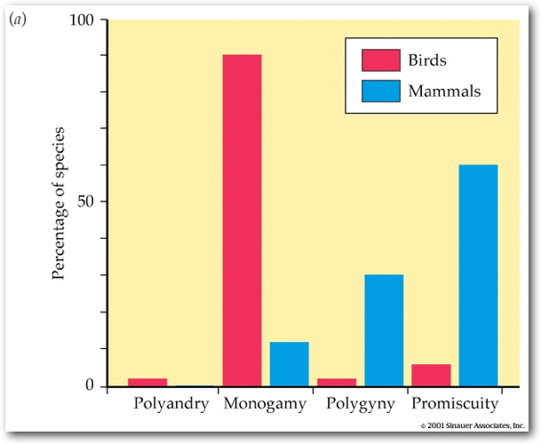

- Primates: 1/2 promiscuous (e.g., chimps); 1/3 polygynous (e.g., gorillas)

## Humans vs. most mammals…

- outward signs of estrous (i.e. higher body temperature, breast swelling, sugar cravings, etc.) less obvious
- copulate throughout the reproductive cycle, not just at estrous
- after ejaculation/orgasm in males and females, oxytocin release has sedative effect
- sex in multiple positions
- couples live in large social groups

## Humans vs. most primates

- large relative size of testes, ejaculate volume, and sperm count vs. most primates;
- spend more time in copulation & copulate with greater frequency than other primates

## Cautionary notes

- Biology isn’t "destiny""
- “Natural” doesn’t mean morally right
- Human behavior shaped by biology AND culture

## Your brain and orgasm

http://www.thevisualmd.com/read_videoguide.php?id_url=1033607627

## Male and female brain *activity* patterns

- Before orgasm
  - Amygdala, fusiform gyrus deactivation
- During orgasm
  - Cerebellar activation
  - Lateral orbitofrontal cortex deactivates
  - Deactivation of amygdala, hippocampus
  - Periaqueductal grey (PAG) activates in men

## Male and female brain *structures* similar

[figure not shown]

[(Joel et al. 2015)](http://doi.org/10.1073/pnas.1509654112)

## Male and female brain *structures* similar

*Consistent with previous findings (14, 15), our analysis of the structure of the human brain, which included most regions of gray and white matter, as well as measures of connectivity, revealed many nondimorphic group-level sex/gender differences in brain structure. There was extensive overlap of the distributions of females and males for all brain regions and connections assessed, irrespective of the type of sample, measure, or analysis (including analysis of absolute brain volumes)…*

[(Joel et al. 2015)](http://doi.org/10.1073/pnas.1509654112)

*This extensive overlap undermines any attempt to distinguish between a “male” and a “female” form for specific brain features…*

[(Joel et al. 2015)](http://doi.org/10.1073/pnas.1509654112)

## But, different connectivity patterns?

[figure not shown]

[(Ingalhalikar et al. 2014)](http://doi.org/10.1073/pnas.1316909110)

*Sex differences are of high scientific and societal interest because of their prominence in behavior of humans and nonhuman species. This work is highly significant because it studies a very large population of 949 youths (8–22 y, 428 males and 521 females) using the diffusion-based structural connectome of the brain, identifying novel sex differences. The results establish that male brains are optimized for intrahemispheric and female brains for interhemispheric communication…*

[(Ingalhalikar et al. 2014)](http://doi.org/10.1073/pnas.1316909110)

*The developmental trajectories of males and females separate at a young age, demonstrating wide differences during adolescence and adulthood. The observations suggest that male brains are structured to facilitate connectivity between perception and coordinated action, whereas female brains are designed to facilitate communication between analytical and intuitive processing modes.*

[(Ingalhalikar et al. 2014)](http://doi.org/10.1073/pnas.1316909110)

## Different sizes in hypothalamic nuclei

- Sexually dimorphic nucleus of the hypothalamus
  - *Dimorphic* means two forms
- Males >> females
- Controls male sexual behavior

## Venus vs. Mars?

[figure not shown]

## Next time…

- Sleep and circadian rhythms

## References

Ingalhalikar, Madhura, Alex Smith, Drew Parker, Theodore D. Satterthwaite, Mark A. Elliott, Kosha Ruparel, Hakon Hakonarson, Raquel E. Gur, Ruben C. Gur, and Ragini Verma. 2014. “Sex Differences in the Structural Connectome of the Human Brain.” *Proceedings of the National Academy of Sciences* 111 (2): 823–28. doi:10.1073/pnas.1316909110.

Joel, Daphna, Zohar Berman, Ido Tavor, Nadav Wexler, Olga Gaber, Yaniv Stein, Nisan Shefi, et al. 2015. “Sex Beyond the Genitalia: The Human Brain Mosaic.” *Proceedings of the National Academy of Sciences* 112 (50): 15468–73. doi:10.1073/pnas.1509654112.

Ulrich-Lai, Yvonne M., and James P. Herman. 2009. “Neural Regulation of Endocrine and Autonomic Stress Responses.” *Nature Reviews Neuroscience* 10 (6): 397–409. doi:10.1038/nrn2647.